# 3η εργασία στατιστική μοντελοποίηση - ΔΠΜΣ ΕΔΕΜΜ

Δημήτρης Ζερκελίδης - 03400049

Άσκηση 1 ~ Poisson

Προσαρμογή του μοντέλου μας με τη χρήση της παλινδρόμησης Poisson. Παρατηρούμε πως έχουμε επεξεργαστεί τη μεταβλητη n την οποία μετατρέψαμε σε offset(log(n)). To n δηλώνει το πλήθος των συμβολαίων. Η χρήση του offset γίνεται για να είναι όλα στην ίδια μονάδα μέτρησης και να μπορούμε να μετράμε το rate(αριθμός αποζημιώσεων ανά συμβόλαιο) ενώ το log, λόγω του ότι έτσι μοντελοποιείται η συνάρτηση poisson εφόσον έχει link function τη λογαριθμική.

```r
file1 <- read.table("/home/zerkes/Desktop/DSML - MASTER/1st semester/STATISTICAL MODELLING/project3/final/asfalies.txt", header=TRUE)
attach(file1)
library(MASS)
library(car)
car_cat <- factor(cartype)
mod_full <- glm(y ~ agecat + car_cat + district + offset(log(n)), family=poisson, data=file1)
summary(mod_full)
```

```
##
## Call:
## glm(formula = y ~ agecat + car_cat + district + offset(log(n)),
##     family = poisson, data = file1)
##
## Deviance Residuals:
##     Min       1Q   Median       3Q      Max
## -1.8590  -0.7506  -0.1297   0.6511   3.2310
##
## Coefficients:
##             Estimate Std. Error z value Pr(>|z|)
## (Intercept) -1.93522    0.05525 -35.030  < 2e-16 ***
## agecat      -0.37628    0.04451  -8.453  < 2e-16 ***
## car_cat2     0.16223    0.05048   3.214 0.001309 **
## car_cat3     0.39535    0.05491   7.200 6.03e-13 ***
## car_cat4     0.56543    0.07215   7.836 4.64e-15 ***
## district     0.21661    0.05853   3.701 0.000215 ***
## ---
## Signif. codes:  0 '***' 0.001 '**' 0.01 '*' 0.05 '.' 0.1 ' ' 1
##
## (Dispersion parameter for poisson family taken to be 1)
##
##     Null deviance: 207.833  on 31  degrees of freedom
## Residual deviance:  41.789  on 26  degrees of freedom
## AIC: 222.15
##
## Number of Fisher Scoring iterations: 4
```

Aπό το παραπάνω summary μπορούμε να δούμε πως όλες οι μεταβλητές μας είναι στατιστικά σημαντικές σύμφωνα με το wald test.Επομένως, οι μεταβλητές αυτές όντως σχετίζονται με τον αριθμό Υ των αποζημιώσεων.

Στον παρακάτω πίνακα μπορούμε να δούμε, όπως και στο summary προηγουμένως, πως όλες οι μεταβλητές είναι στατιστικά σημαντικές και βοηθάνε στην επεξήγηση της εξαρτημένης μεταβλητής.Επιπρόσθετα, μπορούμε να δούμε πως κάθε μεταβλητή συνεισφέρει, στη βελτίωση της Deviance σε σχέση με το null model. Στο Deviance Resid. φαίνεται το πόσο η συγκεκριμένη μεταβλητή μειώνει την ελεγχοσυνάρτηση Deviance όταν εισάγεται ,ενώ στη στήλη Dev. φαίνεται το υπόλοιπο του συνολικού Deviance σε σχέση με το saturated μοντέλο.

Γενικά, η ελεγχοσυνάρτηση Deviance μετράει την απώλεια προσαρμογής σε σχέση με το saturated(κορεσμένο - πλήρες) μοντέλο το οποίο έχει ένα συντελεστή για κάθε δείγμα.

```r
anova(mod_full, test = "Chisq")
```

```
## Analysis of Deviance Table
##
## Model: poisson, link: log
##
## Response: y
##
## Terms added sequentially (first to last)
##
##
##          Df Deviance Resid. Df Resid. Dev  Pr(>Chi)
## NULL                        31    207.833
## agecat    1   62.182        30    145.652 3.132e-15 ***
## car_cat   3   90.925        27     54.727 < 2.2e-16 ***
## district  1   12.938        26     41.789  0.000322 ***
## ---
## Signif. codes:  0 '***' 0.001 '**' 0.01 '*' 0.05 '.' 0.1 ' ' 1
```

Από τα παραπάνω βλέπουμε πως η μεταβλητή car_cat επιφέρει τη μεγαλύτερη βελτίωση στο μοντέλο καθώς μειώνει κατα 90.925 το Deviance της συνάρτησης όταν αυτή περιέχει το agecat μόνο σα μεταβλητή.

**BACKWARD STEPWISE SELECTION MODEL**

θα εξετάσουμε το αν πρέπει να αφαιρέσουμε μεταβλητές από το μοντέλο μας με τη χρήση backward stepwise selection και wald tests.

```r
m1 = step(mod_full, direction="backward", test="Chisq")
```

```
## Start:  AIC=222.15
## y ~ agecat + car_cat + district + offset(log(n))
##
##            Df Deviance    AIC    LRT  Pr(>Chi)
## <none>          41.789 222.15
## - district  1   54.727 233.09 12.938  0.000322 ***
## - agecat    1  107.964 286.32 66.176 4.125e-16 ***
## - car_cat   3  131.713 306.07 89.925 < 2.2e-16 ***
## ---
## Signif. codes:  0 '***' 0.001 '**' 0.01 '*' 0.05 '.' 0.1 ' ' 1
```

```r
summary(m1)
```

```
##
## Call:
## glm(formula = y ~ agecat + car_cat + district + offset(log(n)),
##     family = poisson, data = file1)
##
## Deviance Residuals:
##     Min       1Q   Median       3Q      Max
## -1.8590  -0.7506  -0.1297   0.6511   3.2310
##
## Coefficients:
##             Estimate Std. Error z value Pr(>|z|)
## (Intercept) -1.93522    0.05525 -35.030  < 2e-16 ***
## agecat      -0.37628    0.04451  -8.453  < 2e-16 ***
## car_cat2     0.16223    0.05048   3.214 0.001309 **
## car_cat3     0.39535    0.05491   7.200 6.03e-13 ***
## car_cat4     0.56543    0.07215   7.836 4.64e-15 ***
## district     0.21661    0.05853   3.701 0.000215 ***
## ---
## Signif. codes:  0 '***' 0.001 '**' 0.01 '*' 0.05 '.' 0.1 ' ' 1
##
## (Dispersion parameter for poisson family taken to be 1)
##
##     Null deviance: 207.833  on 31  degrees of freedom
## Residual deviance:  41.789  on 26  degrees of freedom
## AIC: 222.15
##
## Number of Fisher Scoring iterations: 4
```

Παρατηρούμε πως το μοντέλο με όλες τις μεταβλητές είναι το καταλληλότερο σύμφωνα με τον backward αλγόριθμο, με κριτήρio AIC = 222.15.

**ΔΙΑΓΡΑΜΜΑ ΡΥΘΜΟΥ ΑΠΟΖΗΜΙΩΣΕΩΝ Υ ~ ΚΑΤΗΓΟΡΙΑΣ ΗΛΙΚΙΩΝ**

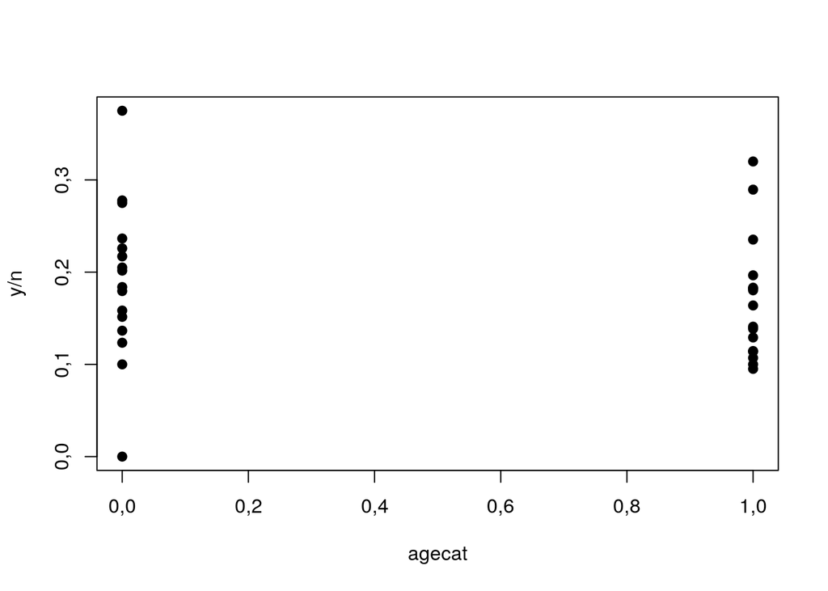

```r
plot(agecat,y/n,pch=19)
```

**ΔΙΑΓΡΑΜΜΑ ΡΥΘΜΟΥ ΑΠΟΖΗΜΙΩΣΕΩΝ Υ ~ ΚΑΤΗΓΟΡΙΑΣ ΑΥΤΟΚΙΝΗΤΩΝ**

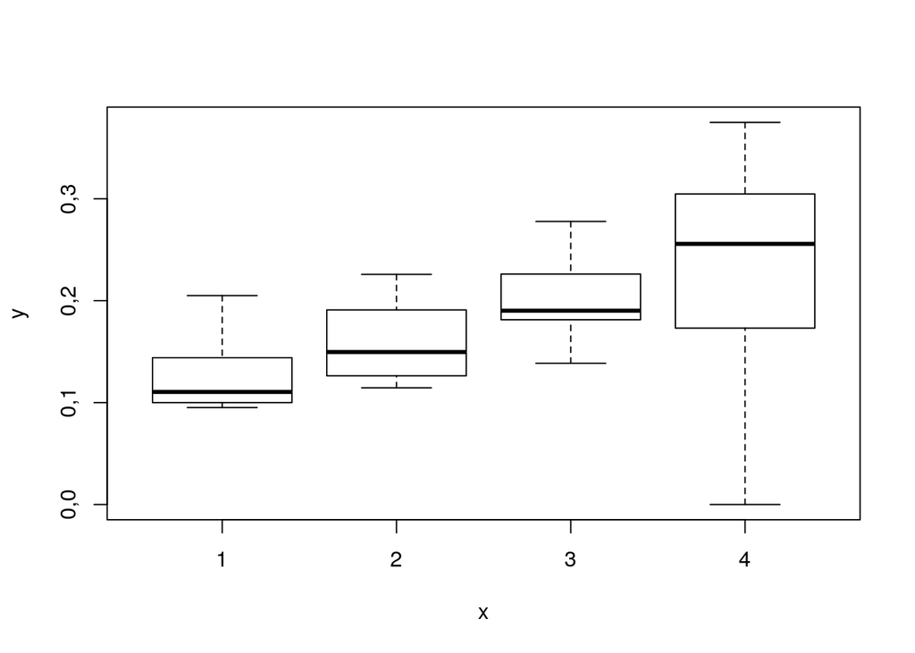

```r
plot(car_cat,y/n,pch=19)
```

**ΔΙΑΓΡΑΜΜΑ ΡΥΘΜΟΥ ΑΠΟΖΗΜΙΩΣΕΩΝ Υ ~ EΠΑΡΧΙΑ/ΠΟΛΗ**

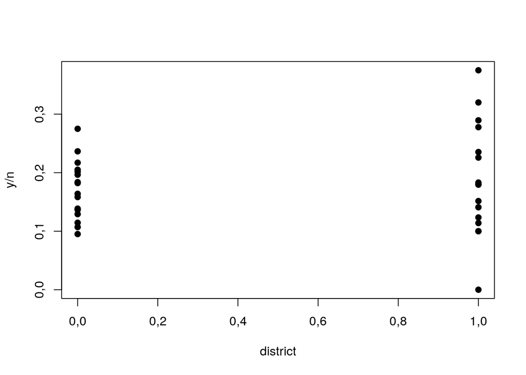

```r
plot(district,y/n,pch=19)
```

**ΈΛΕΓΧΟΣ DEVIANCE ΓΙΑ ΤΟ ΕΠΙΛΕΓΜΕΝΟ ΜΟΝΤΕΛΟ**

Παρακάτω θα κάνουμε χρήση της ελεγχοσυνάρτησης Deviance η οποία ακολουθεί την κατανομή Chi-square για να συγκρίνουμε την απώλεια που έχει το επιλεγμένο μοντέλο από το κορεσμένο (saturated) μοντέλο.

```r
pvalue <-  1 - pchisq(mod_full$deviance,mod_full$df.residual)
pvalue
```

```
## [1] 0,02580847
```

**ΔΙΑΓΝΩΣΤΙΚΟΙ ΕΛΕΓΧΟΙ ~ ΠΡΟΣΑΡΜΟΓΗΣ ~ ΑΤΥΠΩΝ ΣΗΜΕΙΩΝ**

Τα υπόλοιπα χρησιμοποιούνται για να ελέγξουμε την καταλληλότητα του μοντέλου μέσα από γραφικές παραστάσεις. Αρχικά, έχουμε τα index plots των διαφόρων τύπων υπολοίπων ως προς τη σειρά παρατηρήσεων. Η παρουσία μεγάλων ασυνήθιστα υπολοίπων δείχνει ότι το μοντέλο μας δεν είναι ικανοποιητικό.

Επιπλέον, υπάρχουν γραφικές παραστάσεις υπολοίπων έναντι κάθε συμμεταβλητής η του linear predictor (X’β) που μπορούν να αποβούν πολύ χρήσιμες στην εξέταση,ώστε είτε να συμπεριλάβουμε νέες μεταβλητές , είτε να μετασχηματιστεί μια υπάρχουσα. Κάποιο συστηματικό σχήμα δείχνει την πιθανή ύπαρξη προβλήματος στο μοντέλο.

Όλες αυτές οι γραφικές παραστάσεις συμβάλουν στον εντοπισμό των outliers.

Tέλος, υπάρχει και ο έλεγχος των υπολοίπων αν ακολουθούν την κανονική κατανομή για να δείξουμε πόσο καλά έχει προσαρμοστεί το μοντέλο και όχι σαν ένδειξη κανονικότητας των υπολοίπων. Τιμές που ξεφεύγουν από την ευθεία υποδεικνύουν πιθανή μη καλή προσαρμογή του μοντέλου.

Στον παρακάτω κώδικα υπολογίζουμε τα τυποποιημένα σφάλματα pearson, deviance , likelihood.

```r
res_pearson <- residuals(mod_full, type = "pearson")
standard_pearson_residuals <- res_pearson/(sqrt(1-hatvalues(mod_full)))

res_deviance <- residuals(mod_full, type = "deviance")
standard_res_deviance <- rstandard(mod_full)

res_lik <- sign(y - fitted.values(mod_full))*sqrt(hatvalues(mod_full)*standard_pearson_residuals^2 + (1-
hatvalues(mod_full))*standard_res_deviance^2)
```

*INDEX PLOTS*

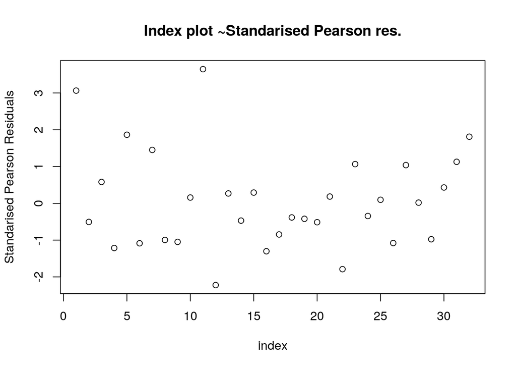

```r
plot(standard_pearson_residuals, main='Index plot ~Standarised Pearson res.', xlab = 'index', ylab = 'Standarised Pearson Residuals')
```

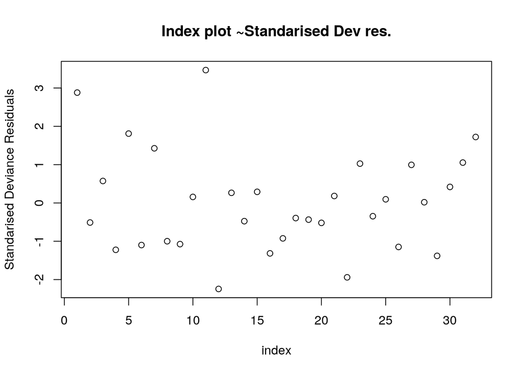

```r
plot(standard_res_deviance, main='Index plot ~Standarised Dev res.', xlab = 'index', ylab = 'Standarised Deviance Residuals')
```

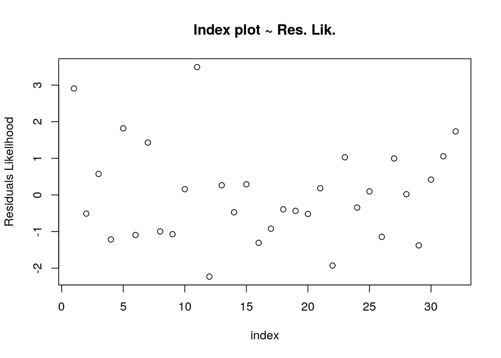

```r
plot(res_lik , main='Index plot ~ Res. Lik.', xlab = 'index', ylab = 'Residuals Likelihood')
```

Από τα παραπάνω index-plots φαίνεται η ύπαρξη μεγάλων υπολοίπων, πράγμα που σημαίνει πως έχουμε κάποια άτυπα σημεία.

*QQ NORMAL PLOTS* Από το διάγραμμα NORMAL Q-Q PLOT βλέπουμε πως αρκετά σημεία ξεφεύγουν από την ευθεία, το οποίο και αυτό με τη σειρά του μας υποδεικνύει την ύπαρξη άτυπων σημείων.

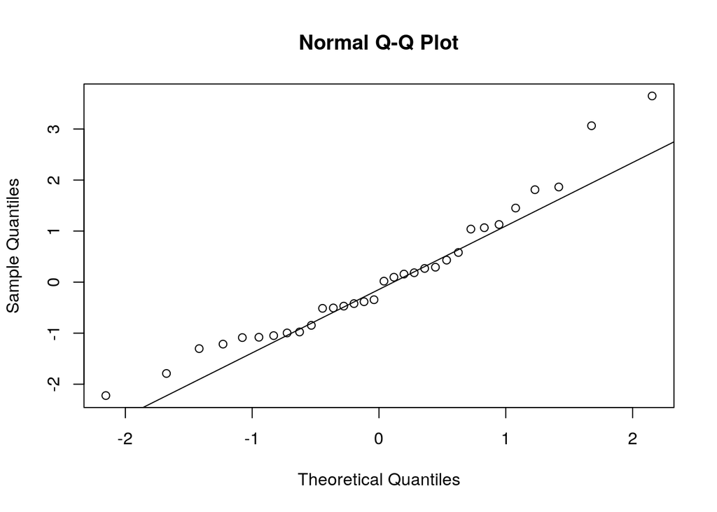

```r
qqnorm(standard_pearson_residuals)
qqline(standard_pearson_residuals)
```

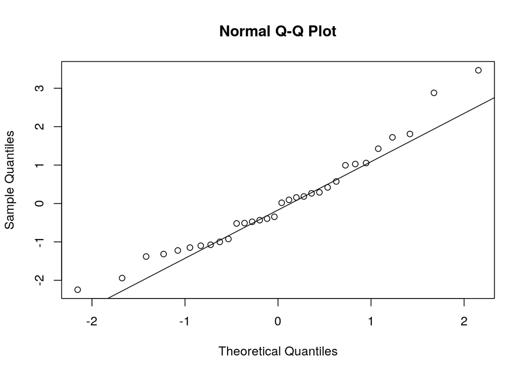

```r
qqnorm(res_deviance/sqrt((1-hatvalues(mod_full))))
qqline(res_deviance/sqrt((1-hatvalues(mod_full))))
```

*PLOTS RESIDUALS ~ COVARIATES AND LINEAR PREDICTOR(FITTED VALUES)*

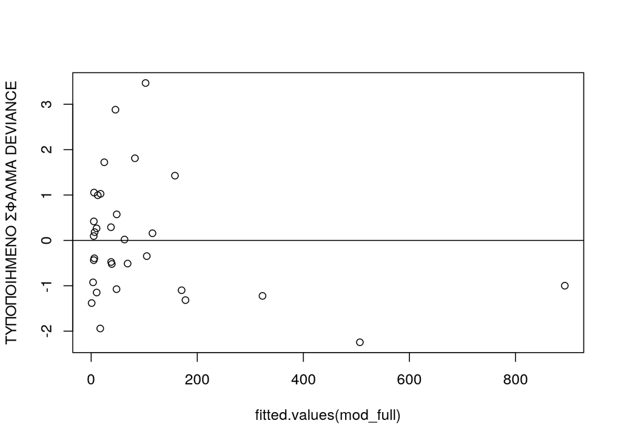

```r
plot(fitted.values(mod_full), res_deviance/sqrt((1-hatvalues(mod_full))), ylab = "ΤΥΠΟΠΟΙΗΜΕΝΟ ΣΦΑΛΜΑ DEVIANCE")
abline(h=0)
```

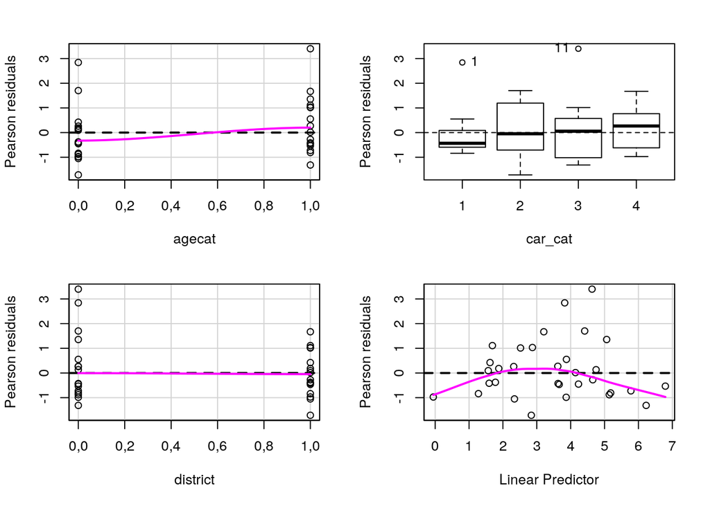

```
##          Test stat Pr(>|Test stat|)
## agecat           0                1
## car_cat
## district         0                1
```

```r
residualPlots(mod_full)
```

Από τα γραφήματα residuals~agecat και residuals~district παίρνουμε κάποια πολύ καλά αποτελέσματα καθώς δεν παρατηρείται κάποια συστηματικότητα και παίρνουμε μια ευθεία γραμμή.

Το γράφημα που περιέχει τις κατηγορίες αμαξιών βλέπουμε πως όσο ανεβαίνουμε κατηγορία ο μέσος ανεβαίνει κατά μέσο όρο. Ενώ επίσης στα 1α και 4α τεταρτημόρια έχουν μεγάλες διαφορές ως προς τη διασπορά τους. Είναι εμφανές πως έχουμε πάλι κάποια outliers.

Τέλος το γράφημα του linear predictor είναι εμφανές πως δεν σκεδάζεται τυχαία αλλά έχουν μια συγκέντρωση προς το κέντρο ενώ εν συνεχεία στο τελευταίο γράφημα βλέπουμε πως πάνε κυρίως κάτω από το 0 οι τιμές.

**CR PLOTS**

*CR PLOTS*

Από τα παρακάτω διαγράμματα βλέπουμε πως οι μεταβλητές μας έχουν μια καλή γραμμικότητα, ενώ θα ήταν δύσκολο να μετασχηματιστούνε εφόσον είναι binary τιμές για να βελτιώσουμε τη γραμμικότητα τους.

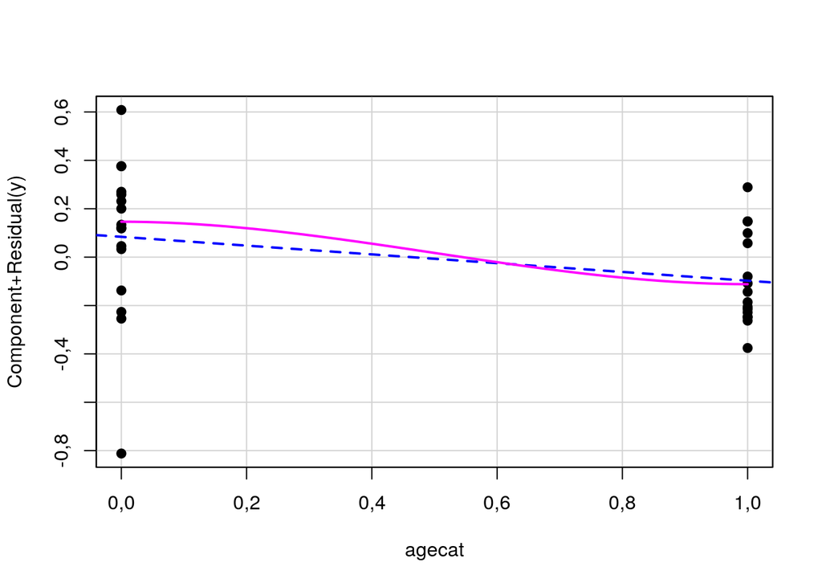

```r
crPlot(mod_full, variable=agecat, pch=19)
```

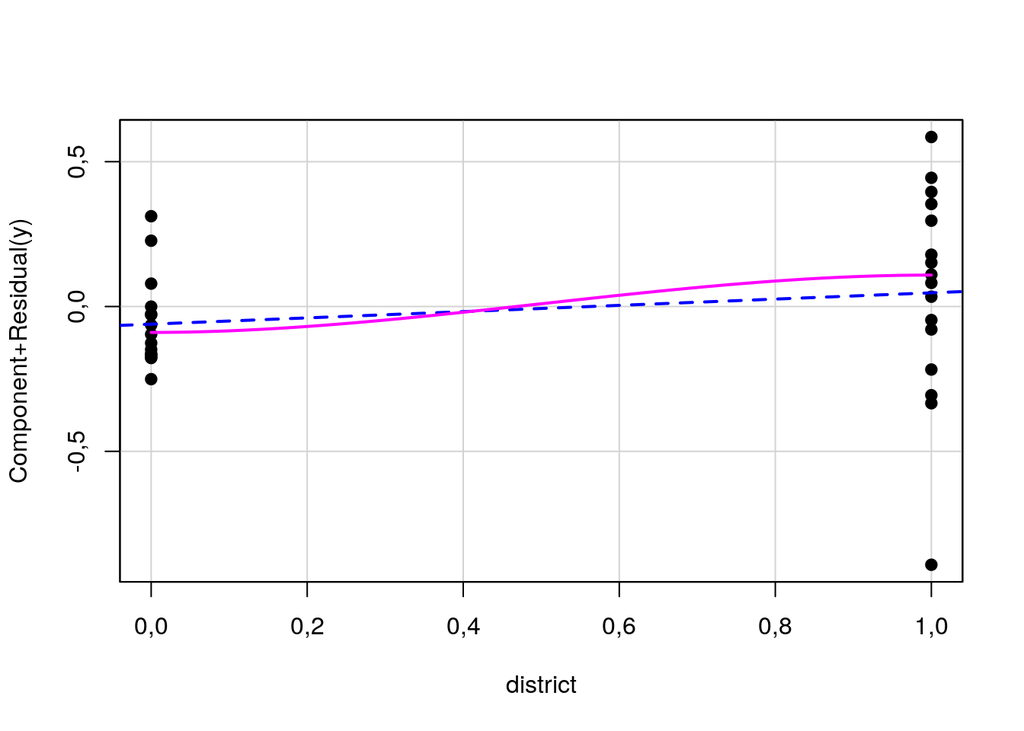

```r
crPlot(mod_full, variable=district, pch=19)
```

**ΕΞΕΤΑΣΗ ΣΗΜΕΙΩΝ ΕΠΙΡΡΟΗΣ**

Στα πρώτα 2 διαγράμματα παρατηρούμε την ύπαρξη κάποιων άτυπων σημείων. Πιο αναλυτικά στο διάγραμμα με τις αποστάσεις Cook παρατηρούμε ότι η παρατήρηση 12 έχει cooks distance μεγαλύτερο του 1.

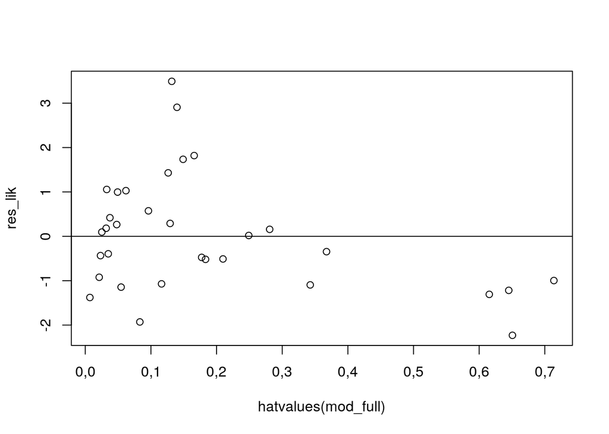

```r
id = c(1:32) # arithmos paratirisewn

#διάγραμμα υπολοίπων πιθανοφάνειας ως προς hii
plot(hatvalues(mod_full),res_lik)
abline(h=0)
```

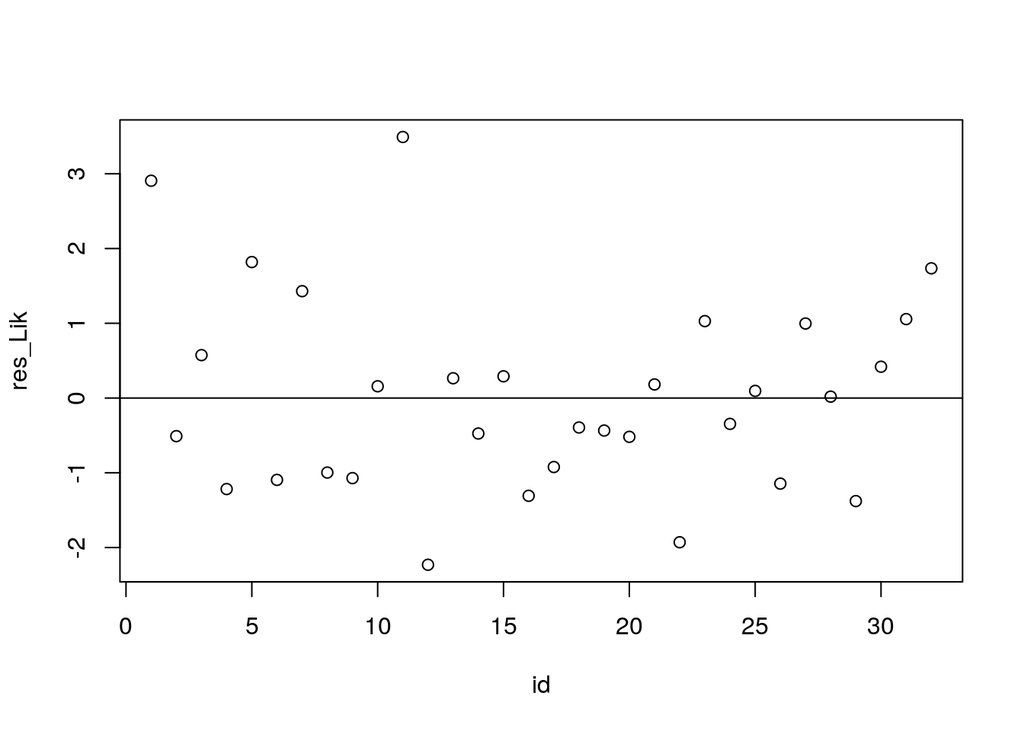

```r
#διάγραμμα residual likelihood vs id
plot(id,res_lik,ylab = "res_Lik")
abline(h=0)
```

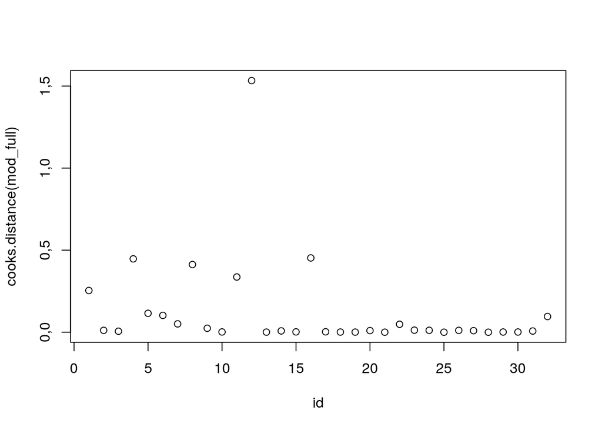

```r
#cooks distance
plot(id,cooks.distance(mod_full))
```

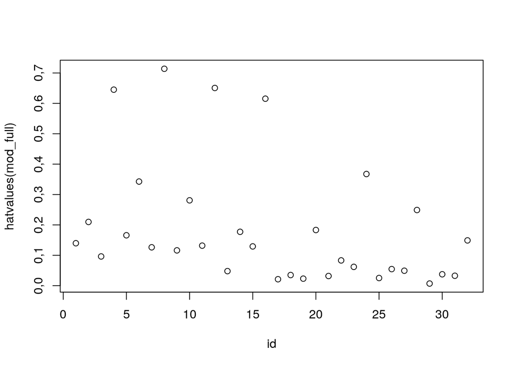

```r
#hat values
plot(id,hatvalues(mod_full))
```

Συγκεκριμένα τα άτυπα σημεία φαίνονται παρακάτω:

```r
cooks.distance(mod_full)[which(cooks.distance(mod_full)>1)]
```

```
##       12
## 1,533511
```

```r
hatvalues(mod_full)[which(hatvalues(mod_full)> 0.1875)]
```

```
##         2         4         6         8        10        12        16
## 0,2097697 0,6450818 0,3426689 0,7138452 0,2808653 0,6506745 0,6154150
##        24        28
## 0,3674769 0,2490220
```

**DEVIANCE R SQUARED**

Παρακάτω φαίνεται ο συντελεστής προσδιορισμού ότι λαμβάνει την τιμή 0,79. Ο συγκεκριμένος αριθμός είναι από 0 εώς 1 και μας δείχνει το ποσοστό της μεταβλητότητας που εξηγείται από το συστηματικό μέρος του μοντέλου.

```r
1 - (mod_full$deviance / mod_full$null.deviance)
```

```
## [1] 0,7989323
```

Μπορούμε να δούμε το συντελεστή αυτόν αν αφαιρέσουμε τα άτυπα σημεία κατά πόσο θα βελτιωθεί.

```r
file2 <- read.table("/home/zerkes/Desktop/DSML - MASTER/1st semester/STATISTICAL MODELLING/project3/final/asfalies_outliers.txt", header=TRUE)
attach(file2)
car_cat <- factor(cartype)
mod_no_outliers <- glm(y ~ agecat + car_cat + district + offset(log(n)), family=poisson, data=file2)


1 - (mod_no_outliers$deviance / mod_no_outliers$null.deviance)
```

```
## [1] 0,8148468
```

Παρατηρούμε πως αφαιρώντας τα outliers η προγνωστική ικανότητα του μοντέλου βελτιώθηκε.

**ΕΡΜΗΝΕΙΑ ΣΥΝΤΕΛΕΣΤΩΝ ΤΟΥ ΕΠΙΛΕΓΜΕΝΟΥ ΜΑΣ ΜΟΝΤΕΛΟΥ**

*agecat coefficient: −0.37628* Ο συντελεστής της κατηγορίας ηλικίας είναι αρνητικός, γεγονός που δείχνει ότι όσο αυξάνεται η ηλικία μειώνεται ο αριθμός των αποζημιώσεων λόγω τροχαίων ατυχημάτων.Ουσιαστικά, αν έχουμε σταθερές όλες τις άλλες μεταβλητές, ο αριθμός των αποζημιώσεων για την ηλικιακή κατηγορία 1 είναι 0.686.. φορές ο αντίστοιχος της κατηγορίας 0 .Αυτό σημαίνει ότι όταν από την κατηγορία 0 που είναι οι μικρότερες ηλικίες μεταβούμε στην κατηγορία 1 που είναι οι μεγαλύτερες, η μεταβλητή των αποζημιώσεων πολλαπλασιάζεται με το e^-0.37.. που σημαίνει πως η μεταβλητή y ελαττώνεται.

*district coefficient:είναι 0.21661* O συντελεστής της κατηγορίας για τις περιοχές είναι θετικός που σημαίνει ότι λειτουργεί αυξητικά στην εξαρτημένη μεταβλητή μας όταν μεταβαίνουμε από την επαρχία(0) στην ομάδα με περιοχή την Αθήνα(1). Εν ολίγοις, κρατώντας τις υπόλοιπες μεταβλητές σταθερές, ο αριθμός αποζημιώσεων για την ομάδα στην περιοχή της Αθήνας είναι e^0.21661=1.242 ο αντίστοιχος αριθμός εξαρτημένης μεταβλητής στην άλλη περιοχή.

*cartype coefficient ~ κατηγορηματική μεταβλητή - 4 levels - 3 dummy variables:* H συγκεκριμένη μεταβλητή μας εξηγείται με τον παρακάτω τρόπο. Θέτει ως σημείο αναφοράς το 1ο επίπεδο ενώ τα άλλα επίπεδα δηλώνουν τη μεταβολή από το επίπεδο αναφοράς(1ο επίπεδο) στο αντίστοιχα δικό τους επίπεδο. Παρακάτω φαίνονται οι συντελεστές για το κάθε επίπεδο σε σχέση με το 1ο. 1->2: 0.16223 1->3: 1.485 1->4: 1.760 Αυτό διαβάζεται για παράδειγμα για το 2ο επίπεδο πως πηγαίνοντας από το 1ο επίπεδο στο 2ο έχουμε exp(0.16223) = 1.176 φορές μεγαλύτερο αριθμό αποζημιώσεων σε σχέση με την 1η κατηγορία κ.ο.κ. Γενικά, βλέπουμε πως όσο ανεβαίνει το επίπεδο ανεβαίνει και το rate των αριθμών των αποζημιώσεων.